# PhD_toolbox_final_exercise

Stefania

April 6, 2017

Rationale of the experiment:

The genome of 18 Oidiodendron maius strains has been sequenced. 9 isolates are metal tolerant (T) and 9 isolates are metal sensitive (S). The mapping has been done using the already available and annotated genome of the strain “Zn” as reference. All the uncovered positions in the genomes of the other isolates, are regions of the genome of O. maius Zn that are absent in the other genomes. Those regions could have evolved under the pressure of the heavy metal polluted soil in which O. maius Zn has been isolated, and could thus cointain genes functionally related with its metal tolerance. In this exercice I focus on the scaffold 35 of the genome.

Aim of the exercise :

Start using the tools we learnt at the course!

Plotting the coverage data of scaffold 35 and observe (a) whether there are differences between T and S in the number of reads covering the scaffold and (b) how the reads map along the scaffold in the different isolates.

### Step 1 : Gather the data from 18 files (one per isolate) to one single file.

The number of reads for each position in scaffold 35 are exported to one single column. The output file will contain 4 columns: the type of isolate (T or S, col n° 1), the isolate name (col n° 2), the position in the scaffold (col n° 3), and the number of reads per each position (col n° 4).

```
## Source of data: 18 files called 'isolate_id'.coverage.bp.sc35.txt
## output: /media/stefania/DATA/sync/files_analisi_genomi/all.cov.bp.sc35.txt
## Type of isolate  Isolate_id:
## S 4E
## T 4H1
## S 5L3
## S 13G
## S 91
## T 505
## T 506
## T 518
## T 523
## T 534
## T 539
## S 1354
## S 1357
## S 1358
## S A
## T Cd
## S E
## T Zn
```

### Step 2: Load the libraries and import the data

### Step 3: (a) How many reads cover scaffold 35 in S vs T isolates?

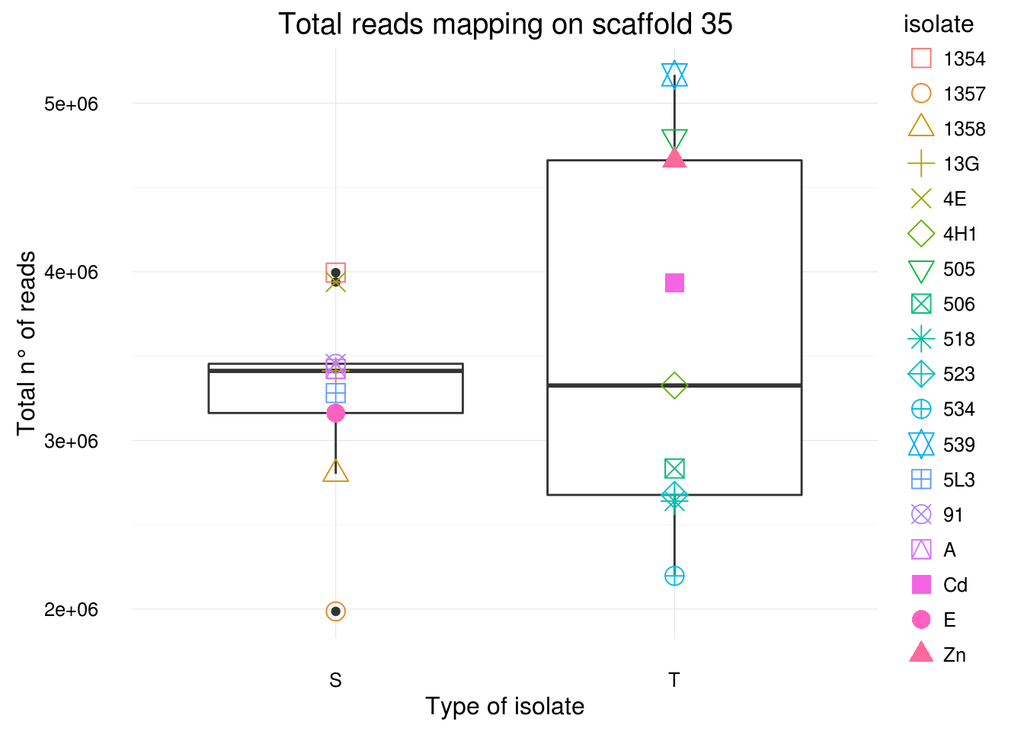

Fig. 1 : Number of reads mapping scaffold 35 in each isolate and distribution of the values for sensitive (S) and tolerant (T) isolates.

### Step 3: (b) How are the reads distributed along the scaffold 35 in the different isolates? Are there completely uncovered bases?

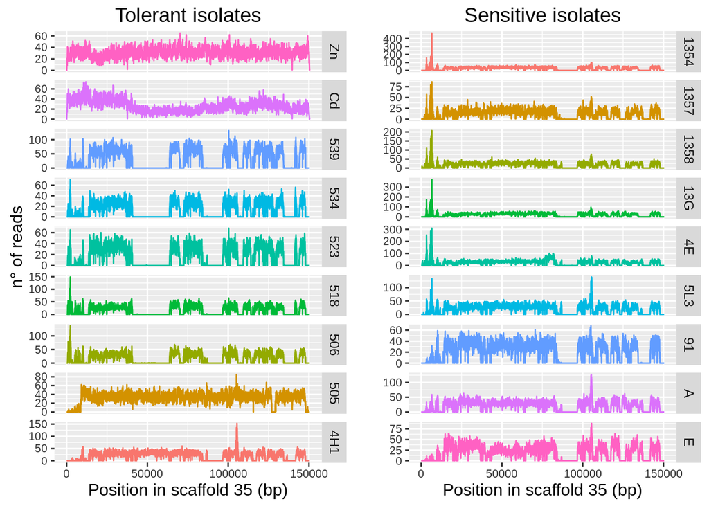

Fig. 2: Mapping of the reads along scaffold 35 in each isolate.

### Conclusions

The coverage of scaffold 35 shows a higher variability in the tolerant than the sensitive isolates. There are regions of the genome of O. maius Zn that are completely missing in many other isolates, both tolerant and sensitive. Next step will be finding the genes annotated in those regions.